Connecting to Mongodb database to the Port: 27017 and Importing data from the database NOSQLProject and collection supplychaindata

```python
import pandas as pd
import numpy as np
import seaborn as sns
import matplotlib.pyplot as plt
```

# Importing necessary Libraries

```python
import xgboost as xgb
import datetime as dt
import calendar,warnings,itertools,matplotlib,keras,shutil
import tensorflow as tf
import statsmodels.api as sm
from datetime import datetime
from sklearn.model_selection import train_test_split,cross_val_score, cross_val_predict
from sklearn import svm,metrics,tree,preprocessing,linear_model
from sklearn.preprocessing import MinMaxScaler,StandardScaler
from sklearn.naive_bayes import GaussianNB
from sklearn.neighbors import KNeighborsClassifier
from sklearn.tree import DecisionTreeRegressor
from sklearn.linear_model import Ridge,LinearRegression,LogisticRegression,ElasticNet, Lasso
from sklearn.ensemble import RandomForestRegressor,RandomForestClassifier, GradientBoostingRegressor,BaggingClassifier,ExtraTreesClassifier
from sklearn.metrics import accuracy_score,mean_squared_error,recall_score,confusion_matrix,f1_score,roc_curve, auc
from sklearn.datasets import load_iris,make_regression
from sklearn.discriminant_analysis import LinearDiscriminantAnalysis
from sklearn.kernel_ridge import KernelRidge
from keras import Sequential
from keras.layers import Dense
from IPython.core import display as ICD

#Hiding the warnings
warnings.filterwarnings('ignore')
```

## Connecting to the mongo server to access 'NOSQLProject' database and in the database we are accesing a specific collection i.e. 'supplychaindata'

```python
from pymongo import MongoClient
client = MongoClient('mongodb://localhost:27017/')
db = client['NOSQLProject']
# Access a specific collection
collection = db['supplychaindata']
```

**Retrieving documents from the collection**

data=collection.find()

```python
data=list(data)
```

```python
import pandas as pd
import numpy as np
df=pd.DataFrame(data)
```

**Displaying the total number of rows, columns and features**

```python
print('1) Number of columns are : ',df.shape[1])
print('2) Number of rows are : ',df.shape[0])
print('3) Total number of data-points :',df.size)
numerical_features = [f for f in df.columns if df[f].dtypes!='O']
print('4) Count of Numerical Features :',len(numerical_features))
cat_features = [c for c in df.columns if df[c].dtypes=='O']
print('5) Count of Categorical Features :',len(cat_features))
```

```
1) Number of columns are :  53
2) Number of rows are :  180519
3) Total number of data-points : 9567507
4) Count of Numerical Features : 28
5) Count of Categorical Features : 25
```

#### There are 53 attributes in our dataset for predicting fraud in the supply chain delivery cycle

#### There are 180519 rows of data each depicting various types of classification variables

#### We have 9567507 data points to use inorder to classify our deciding variable

#### 4) Count of Numerical Features : 28, We determined something is a numerical feature by seeing if the date type is not a 0

#### 5) Count of Categorical Features : 25, We determined something is a numerical feature by seeing if the date type IS a 0

# **Data preprocessing**

Number of Rows and columns in dataset

```python
df.shape
```

```
(180519, 53)
```

```python
df.columns
```

```
Index(['_id', 'Type', 'Days for shipping (real)',
       'Days for shipment (scheduled)', 'Benefit per order',
       'Sales per customer', 'Delivery Status', 'Late_delivery_risk',
       'Category Id', 'Category Name', 'Customer City', 'Customer Country',
       'Customer Email', 'Customer Fname', 'Customer Id', 'Customer Lname',
       'Customer Password', 'Customer Segment', 'Customer State',
       'Customer Street', 'Customer Zipcode', 'Department Id',
       'Department Name', 'Latitude', 'Longitude', 'Market', 'Order City',
       'Order Country', 'Order Customer Id', 'order date (DateOrders)',
       'Order Id', 'Order Item Cardprod Id', 'Order Item Discount',
       'Order Item Discount Rate', 'Order Item Id', 'Order Item Product Price',
       'Order Item Profit Ratio', 'Order Item Quantity', 'Sales',
       'Order Item Total', 'Order Profit Per Order', 'Order Region',
       'Order State', 'Order Status', 'Product Card Id', 'Product Category Id',
       'Product Image', 'Product Name', 'Product Price', 'Product Status',
       'shipping date (DateOrders)', 'Shipping Mode', 'Order Zipcode'],
      dtype='object')
```

#### The various columns we have in our dataset pertaining to supply chain delivery fraud of a company

**Sample Dataset**

```python
df.head(5)
```

|  | _id | Type | Days for shipping (real) | Days for shipment (scheduled) | Benefit per order | Sales per customer | Delivery Status | Late_delivery_risk | Category Id | Category Name | ... | Order Status | Product Card Id | Product Category Id | Product Image | Product Name | Product Price | Product Status | shipping date (DateOrders) | Shipping Mode | Order Zipcode |
| --- | --- | --- | --- | --- | --- | --- | --- | --- | --- | --- | --- | --- | --- | --- | --- | --- | --- | --- | --- | --- | --- |
| 0 | 651438a121e2fc22ab374b26 | DEBIT | 3 | 4 | 91.250000 | 314.640015 | Advance shipping | 0 | 73 | Sporting Goods | ... | COMPLETE | 1360 | 73 | http://images.acmesports.sports/Smart+watch | Smart watch | 327.75 | 0 | 02-03-2018 22:56 | Standard Class | NaN |
| 1 | 651438a121e2fc22ab374b27 | TRANSFER | 5 | 4 | -249.089996 | 311.359985 | Late delivery | 1 | 73 | Sporting Goods | ... | PENDING | 1360 | 73 | http://images.acmesports.sports/Smart+watch | Smart watch | 327.75 | 0 | 1/18/2018 12:27 | Standard Class | NaN |
| 2 | 651438a121e2fc22ab374b28 | CASH | 4 | 4 | -247.779999 | 309.720001 | Shipping on time | 0 | 73 | Sporting Goods | ... | CLOSED | 1360 | 73 | http://images.acmesports.sports/Smart+watch | Smart watch | 327.75 | 0 | 1/17/2018 12:06 | Standard Class | NaN |
| 3 | 651438a121e2fc22ab374b29 | DEBIT | 3 | 4 | 22.860001 | 304.809998 | Advance shipping | 0 | 73 | Sporting Goods | ... | COMPLETE | 1360 | 73 | http://images.acmesports.sports/Smart+watch | Smart watch | 327.75 | 0 | 1/16/2018 11:45 | Standard Class | NaN |
| 4 | 651438a121e2fc22ab374b2a | PAYMENT | 2 | 4 | 134.210007 | 298.250000 | Advance shipping | 0 | 73 | Sporting Goods | ... | PENDING_PAYMENT | 1360 | 73 | http://images.acmesports.sports/Smart+watch | Smart watch | 327.75 | 0 | 1/15/2018 11:24 | Standard Class | NaN |

5 rows × 53 columns

```python
df.info()
```

```
<class 'pandas.core.frame.DataFrame'>
RangeIndex: 180519 entries, 0 to 180518
Data columns (total 53 columns):
 #   Column                         Non-Null Count   Dtype
---  ------                         --------------   -----
 0   _id                            180519 non-null  object
 1   Type                           180519 non-null  object
 2   Days for shipping (real)       180519 non-null  int64
 3   Days for shipment (scheduled)  180519 non-null  int64
 4   Benefit per order              180519 non-null  float64
 5   Sales per customer             180519 non-null  float64
 6   Delivery Status                180519 non-null  object
 7   Late_delivery_risk             180519 non-null  int64
 8   Category Id                    180519 non-null  int64
 9   Category Name                  180519 non-null  object
```

[output cut: 45 more lines]

**An overview of the distribution and central tendencies of the loaded data.**

```python
df.describe()
```

|  | Days for shipping (real) | Days for shipment (scheduled) | Benefit per order | Sales per customer | Late_delivery_risk | Category Id | Customer Id | Customer Zipcode | Department Id | Latitude | ... | Order Item Profit Ratio | Order Item Quantity | Sales | Order Item Total | Order Profit Per Order | Product Card Id | Product Category Id | Product Price | Product Status | Order Zipcode |
| --- | --- | --- | --- | --- | --- | --- | --- | --- | --- | --- | --- | --- | --- | --- | --- | --- | --- | --- | --- | --- | --- |
| count | 180519.000000 | 180519.000000 | 180519.000000 | 180519.000000 | 180519.000000 | 180519.000000 | 180519.000000 | 180516.000000 | 180519.000000 | 180519.000000 | ... | 180519.000000 | 180519.000000 | 180519.000000 | 180519.000000 | 180519.000000 | 180519.000000 | 180519.000000 | 180519.000000 | 180519.0 | 24840.000000 |
| mean | 3.497654 | 2.931847 | 21.974989 | 183.107609 | 0.548291 | 31.851451 | 6691.379495 | 35921.126914 | 5.443460 | 29.719955 | ... | 0.120647 | 2.127638 | 203.772096 | 183.107609 | 21.974989 | 692.509764 | 31.851451 | 141.232550 | 0.0 | 55426.132327 |
| std | 1.623722 | 1.374449 | 104.433526 | 120.043670 | 0.497664 | 15.640064 | 4162.918106 | 37542.461122 | 1.629246 | 9.813646 | ... | 0.466796 | 1.453451 | 132.273077 | 120.043670 | 104.433526 | 336.446807 | 15.640064 | 139.732492 | 0.0 | 31919.279101 |
| min | 0.000000 | 0.000000 | -4274.979980 | 7.490000 | 0.000000 | 2.000000 | 1.000000 | 603.000000 | 2.000000 | -33.937553 | ... | -2.750000 | 1.000000 | 9.990000 | 7.490000 | -4274.979980 | 19.000000 | 2.000000 | 9.990000 | 0.0 | 1040.000000 |
| 25% | 2.000000 | 2.000000 | 7.000000 | 104.379997 | 0.000000 | 18.000000 | 3258.500000 | 725.000000 | 4.000000 | 18.265432 | ... | 0.080000 | 1.000000 | 119.980003 | 104.379997 | 7.000000 | 403.000000 | 18.000000 | 50.000000 | 0.0 | 23464.000000 |
| 50% | 3.000000 | 4.000000 | 31.520000 | 163.990005 | 1.000000 | 29.000000 | 6457.000000 | 19380.000000 | 5.000000 | 33.144863 | ... | 0.270000 | 1.000000 | 199.919998 | 163.990005 | 31.520000 | 627.000000 | 29.000000 | 59.990002 | 0.0 | 59405.000000 |
| 75% | 5.000000 | 4.000000 | 64.800003 | 247.399994 | 1.000000 | 45.000000 | 9779.000000 | 78207.000000 | 7.000000 | 39.279617 | ... | 0.360000 | 3.000000 | 299.950012 | 247.399994 | 64.800003 | 1004.000000 | 45.000000 | 199.990005 | 0.0 | 90008.000000 |
| max | 6.000000 | 4.000000 | 911.799988 | 1939.989990 | 1.000000 | 76.000000 | 20757.000000 | 99205.000000 | 12.000000 | 48.781933 | ... | 0.500000 | 5.000000 | 1999.989990 | 1939.989990 | 911.799988 | 1363.000000 | 76.000000 | 1999.989990 | 0.0 | 99301.000000 |

8 rows × 28 columns

# Data Handling

**Check for Null values in the dataset**

```python
np.sum(df.isna())
```

```
_id                                   0
Type                                  0
Days for shipping (real)              0
Days for shipment (scheduled)         0
Benefit per order                     0
Sales per customer                    0
Delivery Status                       0
Late_delivery_risk                    0
Category Id                           0
Category Name                         0
Customer City                         0
Customer Country                      0
Customer Email                        0
Customer Fname                        0
Customer Id                           0
Customer Lname                        8
Customer Password                     0
Customer Segment                      0
Customer State                        0
Customer Street                       0
Customer Zipcode                      3
Department Id                         0
Department Name                       0
Latitude                              0
Longitude                             0
Market                                0
Order City                            0
Order Country                         0
Order Customer Id                     0
order date (DateOrders)               0
Order Id                              0
Order Item Cardprod Id                0
Order Item Discount                   0
Order Item Discount Rate              0
Order Item Id                         0
Order Item Product Price              0
Order Item Profit Ratio               0
Order Item Quantity                   0
Sales                                 0
Order Item Total                      0
Order Profit Per Order                0
Order Region                          0
Order State                           0
Order Status                          0
Product Card Id                       0
Product Category Id                   0
Product Image                         0
Product Name                          0
Product Price                         0
Product Status                        0
shipping date (DateOrders)            0
Shipping Mode                         0
Order Zipcode                    155679
dtype: int64
```

#### This is an important feature for analysis to find out which zipcode sees the most fraud in the supply chain cycle and which doesnt.

#### A company cna then use the inference and define strategies to that will mittigate the fraud happening in those areas.

**From this we can interpret that null values are present in the columns 'Order Zipcode','Customer zipcode', 'Customer Lname'**

## EDA

**Filling the null values in the columns Zipcode with 0**

```python
df['Customer Zipcode'] = df['Customer Zipcode'].fillna(0)
df['Order Zipcode'] = df['Order Zipcode'].fillna(0)
```

**Getting the full name of the customer by combining the FIrstname and last name column in the dataset**

```python
df['Customer Full Name'] = df['Customer Fname'].astype(str) + df['Customer Lname'].astype(str)
```

```python
df=df.drop(['Customer Fname','Customer Lname'],axis=1)
```

```python
df['Customer Full Name'] = df['Customer Full Name'].str.lower()
```

**In the dataset given all the mail ids are quoted as xxxxx so this is not useful so removing that from the dataset**

```python
df=df.drop(['Customer Email'],axis=1)
```

**In the datset we have observed that the 'Product Status' column includes only one value that is 0 which is 'null' so this is of no use so removing this.**

```python
df=df.drop(['Product Status'],axis=1)
```

**Customer Password is not required for analysis so dropping off that from the data**

```python
df=df.drop(['Customer Password'],axis=1)
```

**We will use the Customer address and zipcode for location of shipment so removing the 'latitude' and 'longitude' from the column**

```python
df=df.drop(['Latitude','Longitude'],axis=1)
```

**Product image is not required for analyzing the delivery and fraud so removing that columns**

```python
df=df.drop(['Product Image'],axis=1)
```

**Dropping other attributes that do not contribute to the analysis the delivery and fraud**

```python
df=df.drop(['Category Id','Customer Id','Department Id','Order Id','Order Item Id'],axis=1)
```

**Different Markets the company is serving across the world**

```python
df['Market'].unique()
```

```
array(['Pacific Asia', 'USCA', 'Africa', 'Europe', 'LATAM'], dtype=object)
```

```python
df.columns
```

```
Index(['_id', 'Type', 'Days for shipping (real)',
       'Days for shipment (scheduled)', 'Benefit per order',
       'Sales per customer', 'Delivery Status', 'Late_delivery_risk',
       'Category Name', 'Customer City', 'Customer Country',
       'Customer Segment', 'Customer State', 'Customer Street',
       'Customer Zipcode', 'Department Name', 'Market', 'Order City',
       'Order Country', 'Order Customer Id', 'order date (DateOrders)',
       'Order Item Cardprod Id', 'Order Item Discount',
       'Order Item Discount Rate', 'Order Item Product Price',
       'Order Item Profit Ratio', 'Order Item Quantity', 'Sales',
       'Order Item Total', 'Order Profit Per Order', 'Order Region',
       'Order State', 'Order Status', 'Product Card Id', 'Product Category Id',
       'Product Name', 'Product Price', 'shipping date (DateOrders)',
       'Shipping Mode', 'Order Zipcode', 'Customer Full Name'],
      dtype='object')
```

**Correlation between the data columns**

```python
correlation_matrix = df.corr()
print(correlation_matrix)
```

```
                               Days for shipping (real)  \
Days for shipping (real)                       1.000000
Days for shipment (scheduled)                  0.515880
Benefit per order                             -0.005101
Sales per customer                             0.001757
Late_delivery_risk                             0.401415
Customer Zipcode                               0.000114
Order Customer Id                              0.003432
Order Item Cardprod Id                        -0.000859
Order Item Discount                            0.002231
Order Item Discount Rate                       0.001467
Order Item Product Price                       0.002185
Order Item Profit Ratio                       -0.004638
Order Item Quantity                           -0.000811
Sales                                          0.001962
Order Item Total                               0.001757
Order Profit Per Order                        -0.005101
Product Card Id                               -0.000859
Product Category Id                           -0.000348
Product Price                                  0.002185
Order Zipcode                                 -0.001630

                               Days for shipment (scheduled)  \
Days for shipping (real)                            0.515880
Days for shipment (scheduled)                       1.000000
Benefit per order                                  -0.000185
Sales per customer                                  0.006445
Late_delivery_risk                                 -0.369352
Customer Zipcode                                   -0.003020
Order Customer Id                                   0.000899
Order Item Cardprod Id                             -0.000431
Order Item Discount                                 0.002897
Order Item Discount Rate                            0.000065
Order Item Product Price                            0.006912
Order Item Profit Ratio                            -0.001822
Order Item Quantity                                -0.002925
Sales                                               0.006327
Order Item Total                                    0.006445
Order Profit Per Order                             -0.000185
Product Card Id                                    -0.000431
```

[output cut: 208 more lines]

```
Customer Zipcode                    0.007208
Order Customer Id                  -0.036172
Order Item Cardprod Id             -0.032911
Order Item Discount                -0.011150
Order Item Discount Rate           -0.000091
Order Item Product Price           -0.023385
Order Item Profit Ratio            -0.000640
Order Item Quantity                 0.015207
Sales                              -0.018715
Order Item Total                   -0.018597
Order Profit Per Order             -0.001606
Product Card Id                    -0.032911
Product Category Id                -0.039712
Product Price                      -0.023385
Order Zipcode                       1.000000
```

#### Days for shipping (real) vs. days for shipment (scheduled)

Correlation coefficient: 0.515880 Strength: Moderate Direction: Positive Interpretation: Orders that take longer to ship are more likely to be shipped late. Possible explanations:

Orders that are more complex or require more processing time may take longer to ship. Orders may be delayed due to unforeseen circumstances, such as bad weather or transportation problems. Retailers may underestimate the time it takes to ship orders, especially during peak periods. Recommendations:

Retailers should strive to accurately estimate shipping times and communicate these estimates to customers upfront. Retailers should have a plan in place to deal with unexpected delays. Retailers should consider offering expedited shipping options to customers who need their orders quickly.

#### Days for shipping (real) vs. late_delivery_risk

Correlation coefficient: 0.401415 Strength: Moderate Direction: Positive Interpretation: Orders that take longer to ship are more likely to be shipped late. Possible explanations:

Orders that are shipped late are more likely to be delayed in transit. Orders that are shipped to remote locations are more likely to be delayed. Customers may be more likely to file a late delivery complaint if their order takes a long time to ship. Recommendations:

Retailers should use a shipping carrier that is reliable and has a good track record of on-time deliveries. Retailers should offer shipping insurance to customers who are concerned about late deliveries. Retailers should have a process in place for handling late delivery complaints quickly and efficiently.

#### Order item product price vs. sales per customer

Correlation coefficient: 0.781781 Strength: Strong Direction: Positive Interpretation: Customers who buy more expensive products tend to spend more money overall. Possible explanations:

Customers who are willing to spend more money on a product are also more likely to spend more money on other products and services. Customers who buy more expensive products may be more affluent and have higher disposable incomes. Retailers may bundle more expensive products together or offer discounts on multiple purchases, which encourages customers to spend more money. Recommendations:

Retailers should offer a variety of price points to appeal to customers with different budgets. Retailers should use cross-selling and upselling techniques to encourage customers to buy more expensive products. Retailers should offer loyalty programs and other rewards to customers who spend more money.

#### Order item discount vs. order item discount rate

Correlation coefficient: 0.659955 Strength: Strong Direction: Positive Interpretation: Orders with higher discounts tend to have higher discount rates. Possible explanations:

Retailers may offer higher discounts on items that are already on sale. Retailers may use tiered discounts, which give customers a higher discount the more they spend. Retailers may offer personalized discounts to customers who have a history of spending money with them. Recommendations:

Retailers should use a variety of discounting strategies to appeal to different customers. Retailers should track the effectiveness of their discounting strategies and make adjustments as needed. Retailers should be careful not to over-discount their products, as this can lead to lower profits.

#### Order item profit ratio vs. order item quantity

Retailers should track the profitability of their products and make adjustments to their pricing and inventory levels as needed. Retailers should use targeted marketing campaigns to promote items with higher profit ratios to customers who are most likely to buy them. Retailers should consider offering bundle discounts on items with lower profit ratios to encourage customers to buy them in larger quantities.

**Heatmap for the correlation**

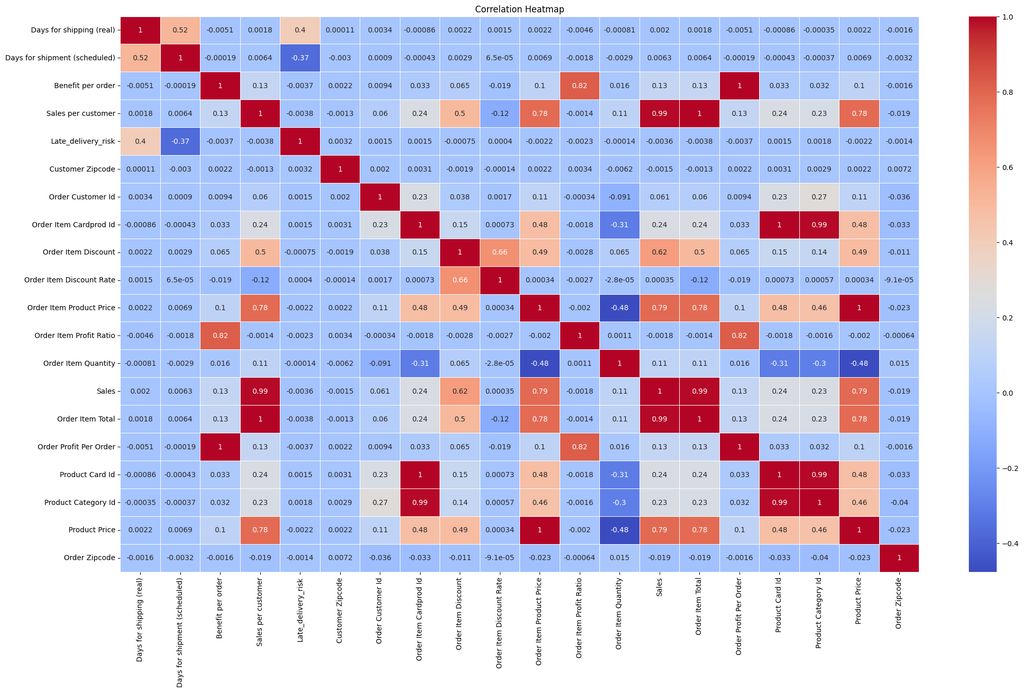

```python
plt.figure(figsize=(25, 14))  # Set the figure size
sns.heatmap(correlation_matrix, annot=True, cmap='coolwarm', linewidths=0.5)
plt.title('Correlation Heatmap')
plt.show()
```

### Suggestions

Based on the inferences above, we can make the following recommendations:

Retailers should strive to ship orders as quickly as possible to reduce the risk of late deliveries. Retailers should offer discounts on products that are less popular or that have been sitting in inventory for a long time. Retailers should focus on selling products with high profit ratios, even if it means selling them in smaller quantities.

From here we can see that the columns 'Customer Email','Product Status','Customer Password','Customer Street','Customer Fname','Customer Lname','Latitude','Longitude','Product Description','Product Image','Order Zipcode','shipping date (DateOrders) have no effect on the order delivery

**Insights from Heatmap:**

1. Columns that are similar with same values but with different metadata (duplicate columns)

   ```
    [Benefit per order], Order Profit per order

    [Sales per customer], Sales, Order Item Total

    [Order Item Product Price],Product Price
   ```

2. Unwanted features(null or less correlated values)

   Product Description

   Product Status

**Removing the duplicate columns to avoid data redundancy**

```python
df=df.drop(['Product Category Id','Order Customer Id','Product Card Id','Product Category Id','Order Profit Per Order','Order Item Cardprod Id','Order Item Total','Sales','Order Item Product Price','Order Item Profit Ratio',],axis=1)
```

## Diagrams

**Analysing Sales from the dataset**

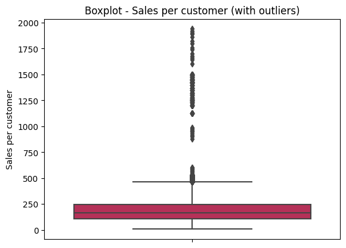

```python
sns.boxplot(data = df, y = 'Sales per customer', palette = 'rocket')
plt.title('Boxplot - Sales per customer (with outliers)');
plt.xlabel('');
```

#### Here we can see that there are many outliers in the sales per customer column and we can also notice how 90% percent of the data spans from 0 - 600 with the average close to 200

**Finding the outlier in Sales per customer column**

```python
Q1 = df['Sales per customer'].quantile(.25)
Q3 = df['Sales per customer'].quantile(.75)
IQR = Q3 - Q1
UL = Q3 + 1.5*(IQR)
LL = Q3 - 1.5*(IQR)
print(UL)
print(LL)
```

```
461.92998880000005
32.86999899999998
```

**The calculated Upper Limit (UL) is approximately 461.93, and the Lower Limit (LL) is approximately 32.87. Any data point in the 'Sales per customer' column that is higher than 461.93 or lower than 32.87 would be considered an outlier based on the 1.5 * IQR [Inter-Quartile Range] rule.**

### Removing the outliers from the Sales per customer column

```python
df['Sales per customer'] = np.where(df['Sales per customer'] < 32.869, 32, np.where(df['Sales per customer'] > 461.930, 461, df['Sales per customer']))
```

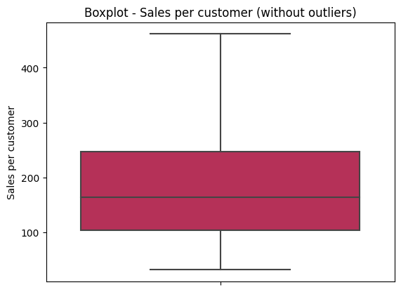

```python
sns.boxplot(data = df, y = 'Sales per customer', palette = 'rocket')
plt.title('Boxplot - Sales per customer (without outliers)');
plt.xlabel('');
```

**Now it can be seen how the data has a skewness to it leaning closer to the below 250 mark than above it.**

**This shows that there have been scattered purchases above 250 or very less compared to the mean/median**

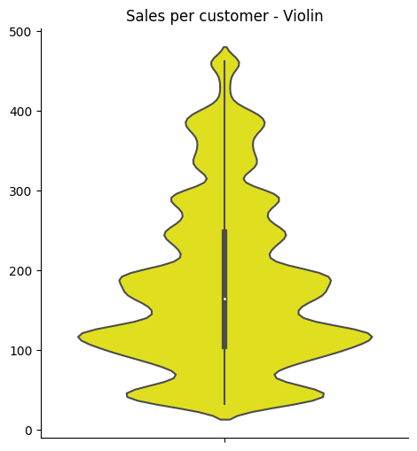

```python
sns.catplot(data = df, y = 'Sales per customer', kind = 'violin', color = 'yellow')
plt.title('Sales per customer - Violin');
plt.ylabel('');
```

#### The claim for skewness is further substantiated by the violin map which has a narrow peak and a narrowing peak which can be inferred as the reduction in occurances of data points in that range.

#### We can see that the majority purchases are in the 100 - 200 region

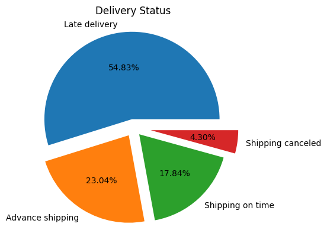

```python
pie = df['Delivery Status'].value_counts().plot(kind = 'pie', autopct = '%.2f%%', explode = [0.1, 0.1, 0.1, 0.2])
plt.title('Delivery Status')
plt.ylabel('');
```

#### This can be seen as a share of our target class ("shipping cancelled") in comparison with the other classes.

```python
df.columns
```

```
Index(['_id', 'Type', 'Days for shipping (real)',
       'Days for shipment (scheduled)', 'Benefit per order',
       'Sales per customer', 'Delivery Status', 'Late_delivery_risk',
       'Category Name', 'Customer City', 'Customer Country',
       'Customer Segment', 'Customer State', 'Customer Street',
       'Customer Zipcode', 'Department Name', 'Market', 'Order City',
       'Order Country', 'order date (DateOrders)', 'Order Item Discount',
       'Order Item Discount Rate', 'Order Item Quantity', 'Order Region',
       'Order State', 'Order Status', 'Product Name', 'Product Price',
       'shipping date (DateOrders)', 'Shipping Mode', 'Order Zipcode',
       'Customer Full Name'],
      dtype='object')
```

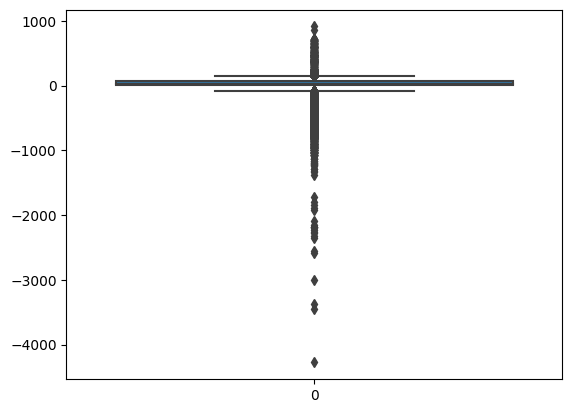

```python
sns.boxplot(df['Benefit per order'])
```

```python
Q1 = df['Benefit per order'].quantile(.25)
Q3 = df['Benefit per order'].quantile(.75)
IQR = Q3 - Q1
UL = Q3 + 1.5*(IQR)
LL = Q3 - 1.5*(IQR)
print(UL)
print(LL)
```

```
151.50000762500002
-21.900001525000008
```

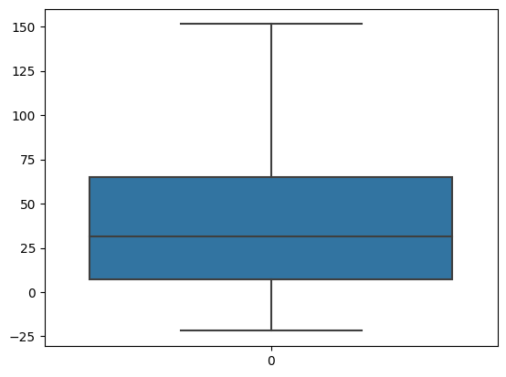

```python
sns.boxplot(df['Benefit per order'])
```

#### We can notice that there are negative numbers in benefit per order which is a loss. Thus the company needs to improve these instances to see real profit.

**Total Sales in each of the market region and the sub market regions**

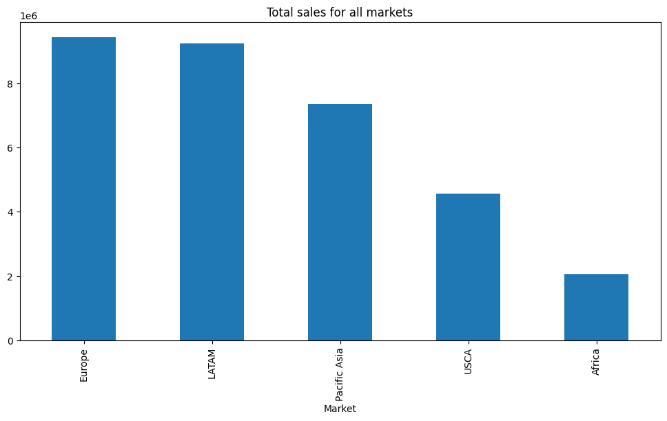

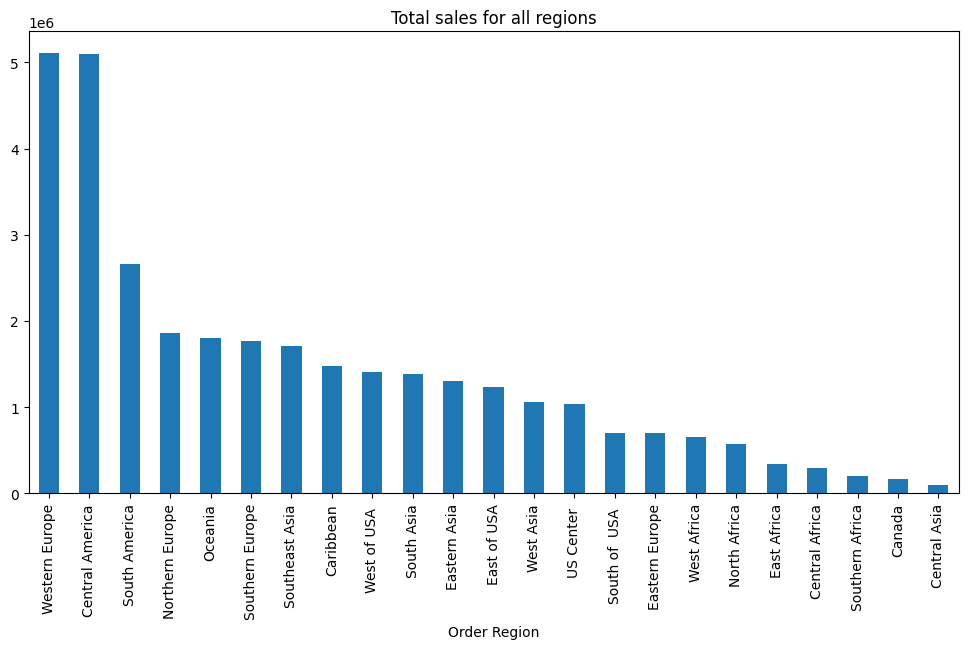

```python
market = df.groupby('Market')
region = df.groupby('Order Region')
plt.figure(1)
market['Sales per customer'].sum().sort_values(ascending=False).plot.bar(figsize=(12,6), title="Total sales for all markets")
plt.figure(2)
region['Sales per customer'].sum().sort_values(ascending=False).plot.bar(figsize=(12,6), title="Total sales for all regions")
```

#### * From the graph, European market has the most number of sales along with LATAM standing very close

#### * Africa has the least number of sales.

#### * Western europe regions and central america recorded highest sales in the sub categories

#### * Canada and Central Asia has the least number of sales this shows that canada does not contribute much to the USCA market which is misleading

### Comparision of sales by product category

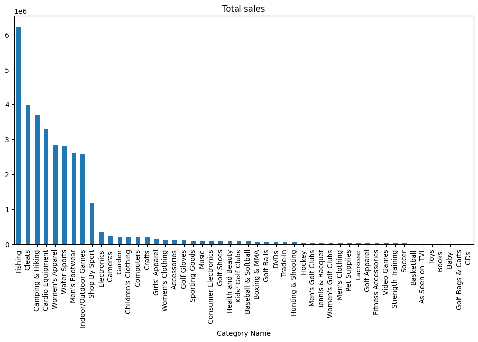

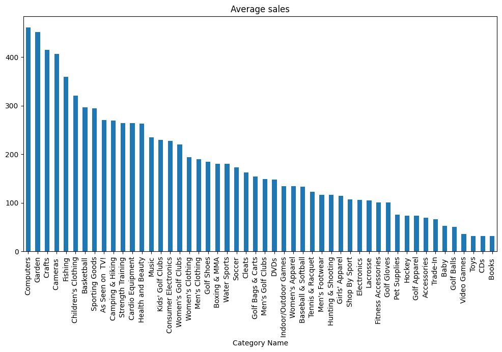

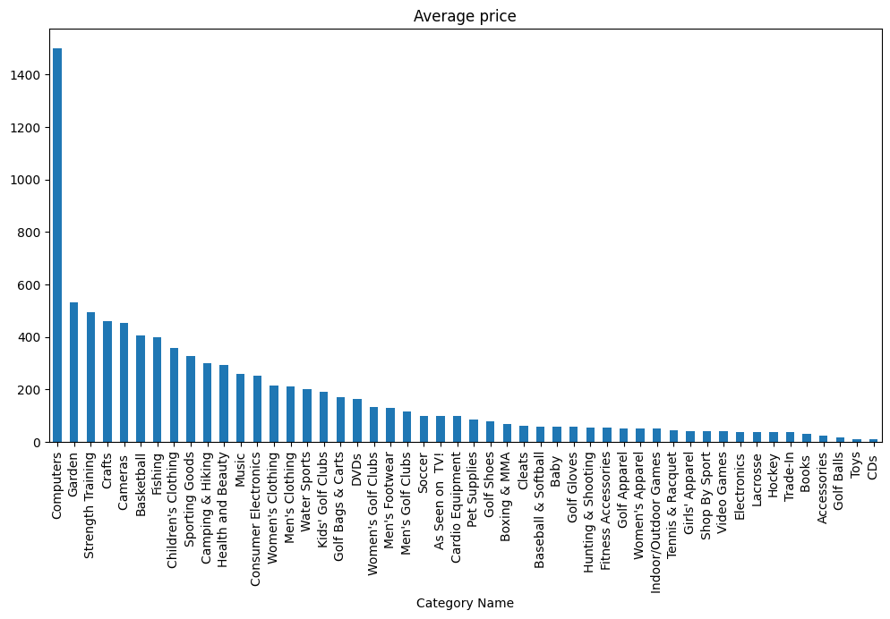

```python
cat = df.groupby('Category Name')
plt.figure(1)
# Total sum of sales for all categories
cat['Sales per customer'].sum().sort_values(ascending=False).plot.bar(figsize=(12,6), title="Total sales")
# Mean sales for all categories
plt.figure(2)
cat['Sales per customer'].mean().sort_values(ascending=False).plot.bar(figsize=(12,6), title="Average sales")
plt.figure(3)
# Mean prices for all categories
cat['Product Price'].mean().sort_values(ascending=False).plot.bar(figsize=(12,6), title="Average price")
```

#### * Given the high correlation between price and sales, it's intriguing to investigate how price impacts sales for different products and to identify any trends in them

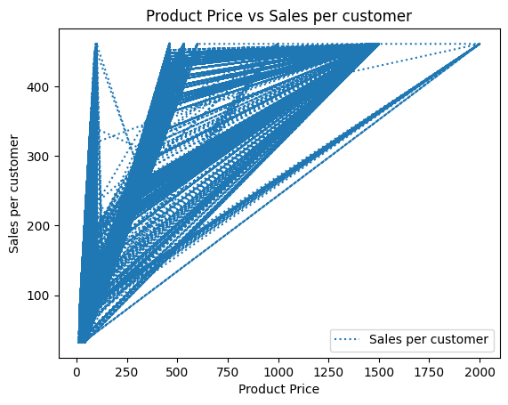

```python
df.plot(x='Product Price', y='Sales per customer',linestyle='dotted',
     markerfacecolor='blue', markersize=12)
plt.title('Product Price vs Sales per customer')
plt.xlabel('Product Price')
plt.ylabel('Sales per customer')
plt.show()
```

#### It can be observed that prices attribute has a linear relation with sales.

**Extracting the the details of the various dates and times of various attributes**

```python
df['order_year']= pd.DatetimeIndex(df['order date (DateOrders)']).year
df['order_month'] = pd.DatetimeIndex(df['order date (DateOrders)']).month
df['order_week_day'] = pd.DatetimeIndex(df['order date (DateOrders)']).day_name()
df['order_hour'] = pd.DatetimeIndex(df['order date (DateOrders)']).hour
df['order_month_year'] = pd.to_datetime(df['order date (DateOrders)']).dt.to_period('M')
```

[output not shown]

```python
df=df.drop(['order date (DateOrders)'],axis=1)
```

**Infering the sales per customer with order month year filter. so we can view them average sales for each of the quarter**

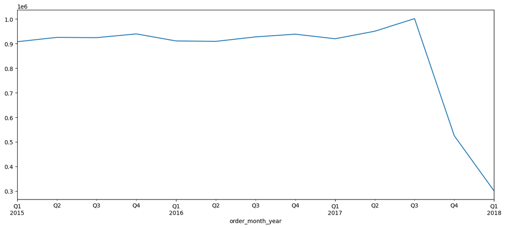

```python
quater= df.groupby('order_month_year')
quartersales=quater['Sales per customer'].sum().resample('Q').mean().plot(figsize=(15,6))
```

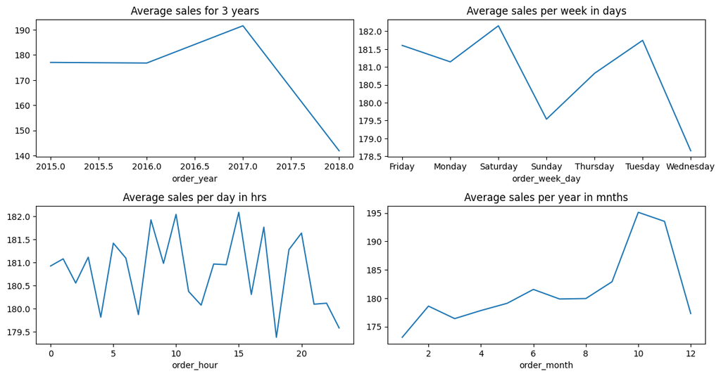

```python
plt.figure(figsize=(10,12))
plt.subplot(4, 2, 1)
quater= df.groupby('order_year')
quater['Sales per customer'].mean().plot(figsize=(12,12),title='Average sales for 3 years')
plt.subplot(4, 2, 2)
days=df.groupby("order_week_day")
days['Sales per customer'].mean().plot(figsize=(12,12),title='Average sales per week in days')
plt.subplot(4, 2, 3)
hrs=df.groupby("order_hour")
hrs['Sales per customer'].mean().plot(figsize=(12,12),title='Average sales per day in hrs')
plt.subplot(4, 2, 4)
mnth=df.groupby("order_month")
mnth['Sales per customer'].mean().plot(figsize=(12,12),title='Average sales per year in mnths')
plt.tight_layout()
plt.show()
```

#### * Saturdays saw the highest average sales, while Wednesdays recorded the lowest.

#### * Sales remained relatively consistent throughout the day, regardless of the time.

## Comparision on the basis of Payment type in various sub regions

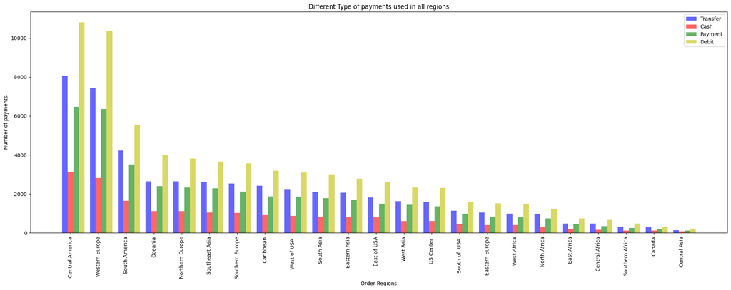

```python
a = df[(df['Type'] == 'TRANSFER')]
b = df[(df['Type'] == 'CASH')]
c = df[(df['Type'] == 'PAYMENT')]
d = df[(df['Type'] == 'DEBIT')]
count1=a['Order Region'].value_counts()
count2=b['Order Region'].value_counts()
count3=c['Order Region'].value_counts()
count4=d['Order Region'].value_counts()
names=df['Order Region'].value_counts().keys()
n_groups=23
fig,ax = plt.subplots(figsize=(20,8))
index=np.arange(n_groups)
bar_width=0.2
opacity=0.6
type1=plt.bar(index,count1,bar_width,alpha=opacity,color='b',label='Transfer')
type2=plt.bar(index+bar_width,count2,bar_width,alpha=opacity,color='r',label='Cash')
type3=plt.bar(index+bar_width+bar_width,count3,bar_width,alpha=opacity,color='g',label='Payment')
type4=plt.bar(index+bar_width+bar_width+bar_width,count4,bar_width,alpha=opacity,color='y',label='Debit')
plt.xlabel('Order Regions')
plt.ylabel('Number of payments')
plt.title('Different Type of payments used in all regions')
plt.legend()
plt.xticks(index+bar_width,names,rotation=90)
plt.tight_layout()
plt.show()
```

#### Debit type is most preferred payment method by people in all regions, Cash payment being the least preferred method.

#### We can also notice that the proportion of the payments breakdown are very similar in every subregion

# **Analysis of loss on sales by different Product categories and Region of sales**

```
Total revenue lost with orders -611744.7000739169
```

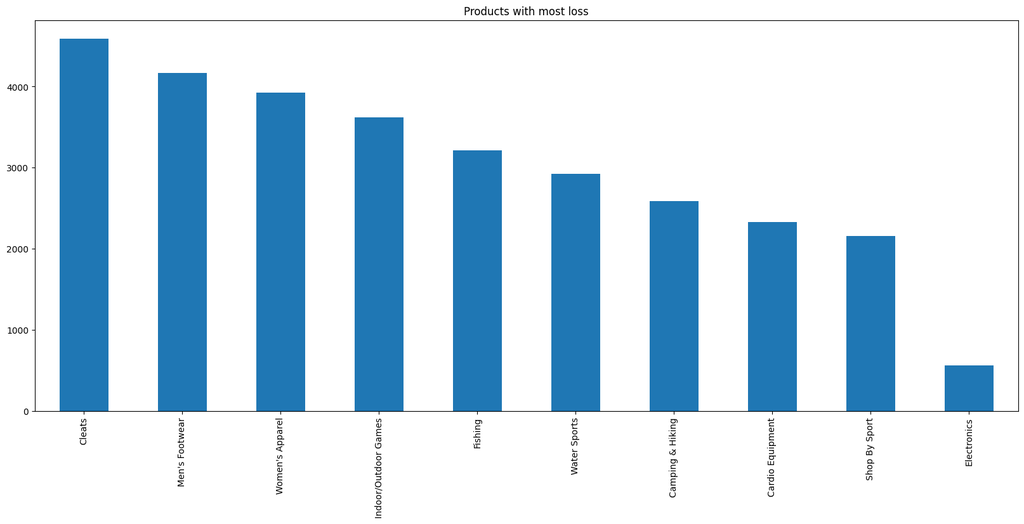

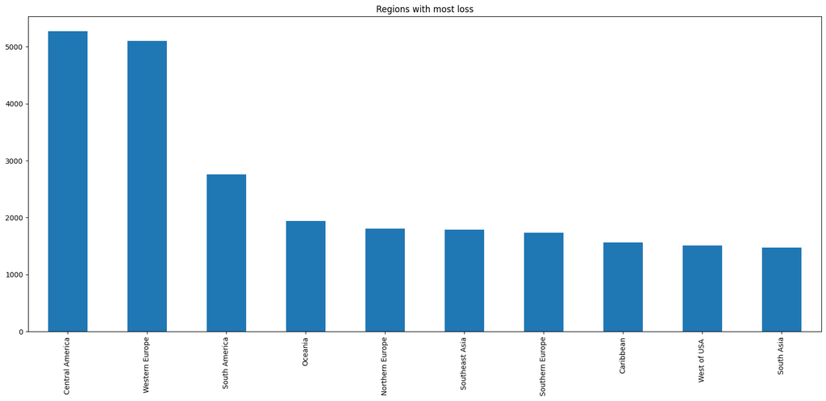

```python
loss = df[(df['Benefit per order']<0)]
#Plotting top 10 products with most loss
plt.figure(1)
loss['Category Name'].value_counts().nlargest(10).plot.bar(figsize=(20,8), title="Products with most loss")
plt.figure(2)
loss['Order Region'].value_counts().nlargest(10).plot.bar(figsize=(20,8), title="Regions with most loss")
#Sum of total sales which are lost
print('Total revenue lost with orders',loss['Benefit per order'].sum())
```

#### * Cleats emerge as the category with the highest loss in sales, closely followed by Mens footwear.

#### * The regions experiencing the most significant lost sales are Central America and Western Europe.

#### * These lost sales could be attributed to suspected frauds or delayed deliveries which need to be improved

#### * These losses also coraborate the trend seen in the negative data points of the Benefits per order attribute

## **Checking for fraud regions and used payment types for suspected frauds**

```python
df['Type'].unique()
```

```
array(['DEBIT', 'TRANSFER', 'CASH', 'PAYMENT'], dtype=object)
```

**Checking for the order status as suspected fraud for each category**

```python
fraud_DEBIT = df[(df['Type'] == 'DEBIT')&(df['Order Status'] == 'SUSPECTED_FRAUD')]
fraud_DEBIT['Order Region'].value_counts()
```

```
Series([], Name: Order Region, dtype: int64)
```

```python
fraud_CASH = df[(df['Type'] == 'CASH')&(df['Order Status'] == 'SUSPECTED_FRAUD')]
fraud_CASH['Order Region'].value_counts()
```

```
Series([], Name: Order Region, dtype: int64)
```

```python
fraud_PAYMENT = df[(df['Type'] == 'PAYMENT')&(df['Order Status'] == 'SUSPECTED_FRAUD')]
fraud_PAYMENT['Order Region'].value_counts()
```

```
Series([], Name: Order Region, dtype: int64)
```

```python
fraud_TRANSFER = df[(df['Type'] == 'TRANSFER')&(df['Order Status'] == 'SUSPECTED_FRAUD')]
fraud_TRANSFER['Order Region'].value_counts()
```

```
Western Europe     705
Central America    631
South America      361
West of USA        236
Oceania            229
Southern Europe    223
Caribbean          190
Southeast Asia     187
Northern Europe    170
Eastern Asia       156
East of USA        150
West Asia          147
South Asia         144
US Center          121
North Africa        75
Eastern Europe      74
West Africa         71
South of  USA       66
Southern Africa     32
East Africa         31
Canada              29
Central Africa      28
Central Asia         6
Name: Order Region, dtype: int64
```

#### * Here have observed that payment type PAYMENT, DEBIT, CASH have no suspected fraud values in the order status column

#### * Most of the frauds have occured in the Transfer mode of payment, which is also the second highest form of payment method used the by the customers. Thus this can not be eiliminated and a new strategy to stop the fraud has to be developed.

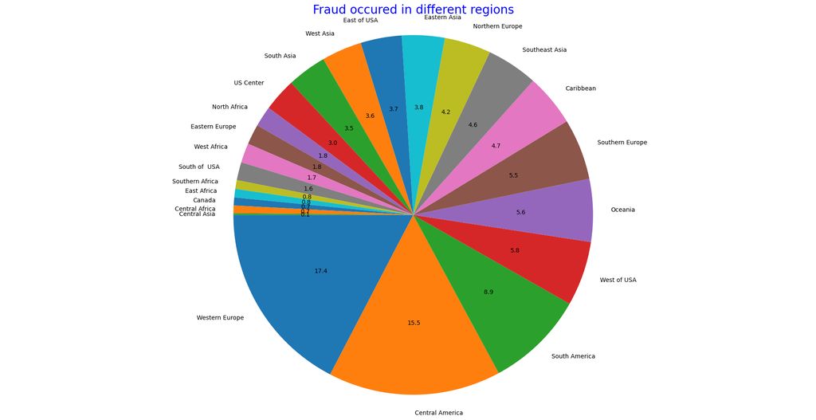

```python
fraud = df[(df['Order Status'] == 'SUSPECTED_FRAUD') & (df['Type'] == 'TRANSFER')]#separating orders with suspected fraud
#Plotting pie chart with respect to order region
fraud=fraud['Order Region'].value_counts().plot.pie(figsize=(24,12),startangle=180,autopct='%.1f',)
plt.title("Fraud occured in different regions",size=20,color='b')
plt.ylabel(" ")
fraud.axis('equal')
plt.show()
```

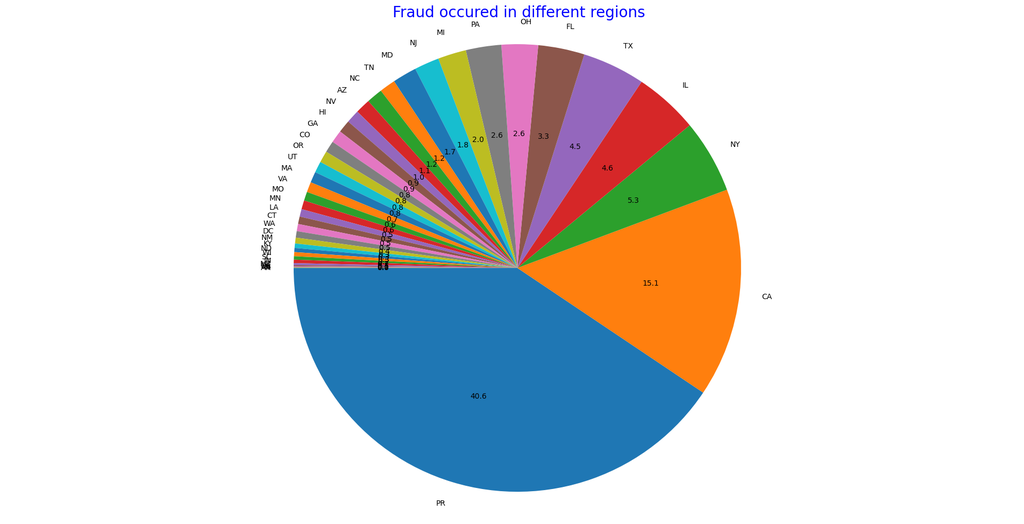

```python
fraud = df[(df['Order Status'] == 'SUSPECTED_FRAUD') & (df['Type'] == 'TRANSFER')]#separating orders with suspected fraud
#Plotting pie chart with respect to customer states
fraud=fraud['Customer State'].value_counts().plot.pie(figsize=(24,12),startangle=180,autopct='%.1f',)
plt.title("Fraud occured in different regions",size=20,color='b')
plt.ylabel(" ")
fraud.axis('equal')
plt.show()
```

#### * From this pie chart we can see that the highest number of frauds have occured in Western Europe which is approximately 17.4%.

#### * Then Central American region has a fraud % ofapproximately 15.5%

#### * Least fraud occured in central asia.

#### * It should also be noted that these fraud values are correlated with the amount of sales. Which also makes sense as more the # of transactions the more opportunity to encounter various types of customers with various intentions.

### **Amount attributed to fraud per region**

```python
amount = df[(df['Order Region'] == 'Western Europe')&(df['Order Status'] == 'SUSPECTED_FRAUD')]
amount['Sales per customer'].sum()
```

```
132182.34130894003
```

```python
amount = df[(df['Order Region'] == 'Central America')&(df['Order Status'] == 'SUSPECTED_FRAUD')]
amount['Sales per customer'].sum()
```

```
113357.85101384
```

```python
amount = df[(df['Customer State'] == 'PR')&(df['Order Status'] == 'SUSPECTED_FRAUD')]
amount['Sales per customer'].sum()
```

```
300416.77283194
```

```python
amount = df[(df['Customer State'] == 'CA')&(df['Order Status'] == 'SUSPECTED_FRAUD')]
amount['Sales per customer'].sum()
```

```
107595.64112178
```

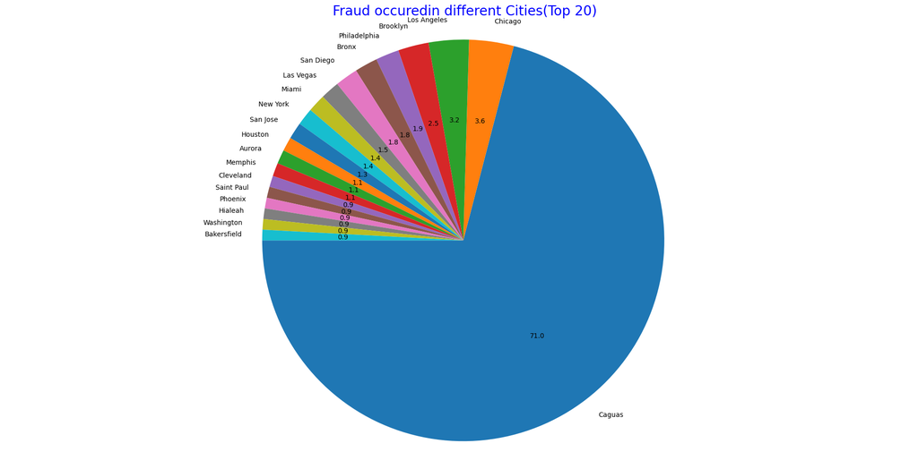

```python
fraud = df[(df['Order Status'] == 'SUSPECTED_FRAUD') & (df['Type'] == 'TRANSFER')]#separating orders with suspected fraud
#Plotting pie chart with respect to order region
fraud=fraud['Customer City'].value_counts().nlargest(20).plot.pie(figsize=(24,12),startangle=180,autopct='%.1f',)
plt.title("Fraud occured in different Cities(Top 20)",size=20,color='b')
plt.ylabel(" ")
fraud.axis('equal')
plt.show()
```

```python
amount = df[(df['Customer City'] == 'Caguas')&(df['Order Status'] == 'SUSPECTED_FRAUD')]
amount['Sales per customer'].sum()
```

[output not shown]

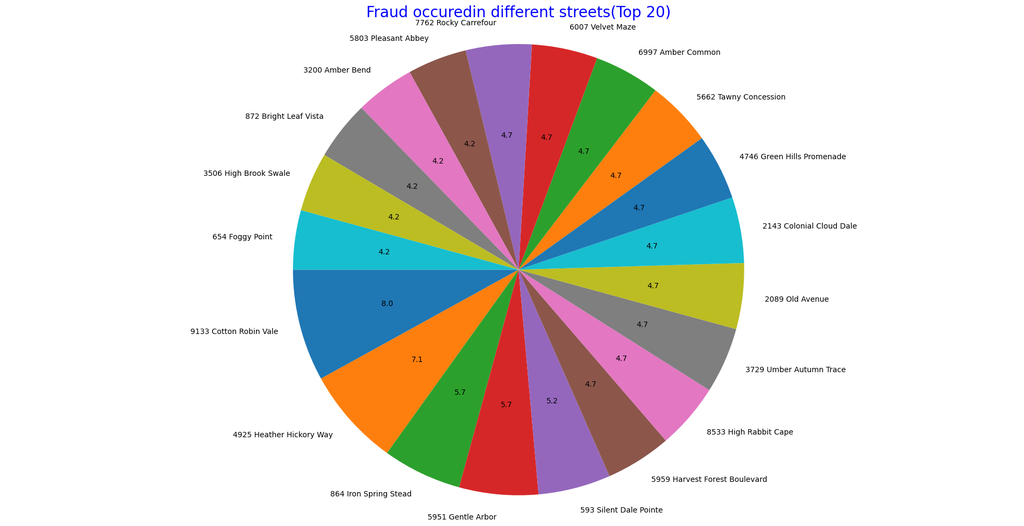

```python
fraud = df[(df['Order Status'] == 'SUSPECTED_FRAUD') & (df['Type'] == 'TRANSFER')]#separating orders with suspected fraud
#Plotting pie chart with respect to order region
fraud=fraud['Customer Street'].value_counts().nlargest(20).plot.pie(figsize=(24,12),startangle=180,autopct='%.1f',)
plt.title("Fraud occuredin different streets(Top 20)",size=20,color='b')
plt.ylabel(" ")
fraud.axis('equal')
plt.show()
```

#### This shows that rather than there being a racquet from a city it might be just one customer who is abusing the leeway given to them by taking advantage of the company's delivery and payment policies

```python
amount = df[(df['Customer Street'] == '9133 Cotton Robin Vale')&(df['Order Status'] == 'SUSPECTED_FRAUD')]
amount['Sales per customer'].sum()
```

```
2990.9400596400005
```

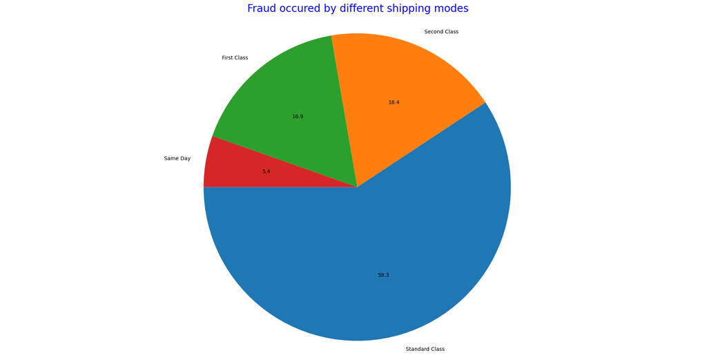

```python
fraud = df[(df['Order Status'] == 'SUSPECTED_FRAUD') & (df['Type'] == 'TRANSFER')]#separating orders with suspected fraud
#Plotting pie chart with respect to order region
fraud=fraud['Shipping Mode'].value_counts().plot.pie(figsize=(24,12),startangle=180,autopct='%.1f',)
plt.title("Fraud occured by different shipping modes",size=20,color='b')
plt.ylabel(" ")
fraud.axis('equal')
plt.show()
```

#### It can be inferred that more caution needs to be deployed for standard shipping to avoid fraudulent activites

```python
amount = df[(df['Shipping Mode'] == 'Standard Class')&(df['Order Status'] == 'SUSPECTED_FRAUD')]
#Plotting bar chart for top 10 most suspected fraud customers
amount['Sales per customer'].sum()
```

```
429953.13429462997
```

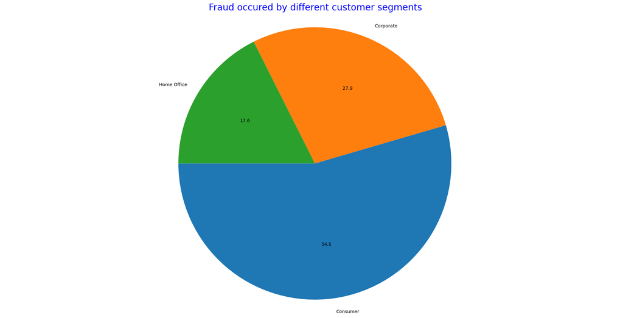

```python
fraud = df[(df['Order Status'] == 'SUSPECTED_FRAUD') & (df['Type'] == 'TRANSFER')]#separating orders with suspected fraud
#Plotting pie chart with respect to order region
fraud=fraud['Customer Segment'].value_counts().plot.pie(figsize=(24,12),startangle=180,autopct='%.1f',)
plt.title("Fraud occured by different customer segments",size=20,color='b')
plt.ylabel(" ")
fraud.axis('equal')
plt.show()
```

### Fraud analysis by product category

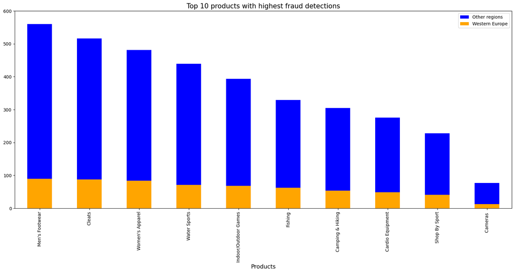

```python
fraud = df[(df['Order Status'] == 'SUSPECTED_FRAUD')] #
high_fraud = df[(df['Order Status'] == 'SUSPECTED_FRAUD') &(df['Order Region'] == 'Western Europe')]
#Plotting bar chart for top 10 most suspected fraud department in all regions
fraud1=fraud['Category Name'].value_counts().nlargest(10).plot.bar(figsize=(20,8), title="Fraud Category",color='blue')
#Plotting bar chart for top 10 most suspected fraud department in Western Europe
fraud2=high_fraud['Category Name'].value_counts().nlargest(10).plot.bar(figsize=(20,8), title="Fraud product in Western Europe",color='orange')
plt.legend(["Other regions", "Western Europe"])
plt.title("Top 10 products with highest fraud detections", size=15)
plt.xlabel("Products", size=13)
plt.ylim(0,600)
plt.show()
```

#### * Highest fraud is done in the Men's Footwear category followed by cleats

#### * Least frauds are occured in cameras product category

```python
amount = df[(df['Category Name'] == "Men's Footwear")&(df['Order Status'] == 'SUSPECTED_FRAUD')]
amount['Sales per customer'].sum()
```

```
60165.33955298
```

#### Though men's footwear has the highest fraud amount, this may not have as significant of an effect as a smaller amount of fraud in a different product category such as cameras, which tend to be more expensive than men's footwear as one camera could be worht the total amount in fraud in footwear category

```python
a=df[(df['Late_delivery_risk']==0)&(df['Order Status']=='SUSPECTED_FRAUD')]
a
```

|  | _id | Type | Days for shipping (real) | Days for shipment (scheduled) | Benefit per order | Sales per customer | Delivery Status | Late_delivery_risk | Category Name | Customer City | ... | Product Price | shipping date (DateOrders) | Shipping Mode | Order Zipcode | Customer Full Name | order_year | order_month | order_week_day | order_hour | order_month_year |
| --- | --- | --- | --- | --- | --- | --- | --- | --- | --- | --- | --- | --- | --- | --- | --- | --- | --- | --- | --- | --- | --- |
| 10 | 651438a121e2fc22ab374b30 | TRANSFER | 6 | 2 | 130.580002 | 272.029999 | Shipping canceled | 0 | Sporting Goods | Caguas | ... | 327.750000 | 1/19/2018 9:18 | Second Class | 0.0 | germaneshort | 2018 | 1 | Saturday | 9 | 2018-01 |
| 24 | 651438a121e2fc22ab374b3e | TRANSFER | 2 | 2 | 90.279999 | 288.420013 | Shipping canceled | 0 | Sporting Goods | Billings | ... | 327.750000 | 1/15/2018 4:24 | Second Class | 0.0 | simonevance | 2018 | 1 | Saturday | 4 | 2018-01 |
| 183 | 651438a121e2fc22ab374bdd | TRANSFER | 5 | 4 | 28.850000 | 128.220001 | Shipping canceled | 0 | Electronics | Freeport | ... | 44.990002 | 5/13/2016 17:42 | Standard Class | 77041.0 | patriciapetersen | 2016 | 5 | Sunday | 17 | 2016-05 |
| 184 | 651438a121e2fc22ab374bde | TRANSFER | 5 | 4 | 133.910004 | 278.970001 | Shipping canceled | 0 | Cardio Equipment | Fort Washington | ... | 99.989998 | 04-07-2016 19:51 | Standard Class | 85234.0 | juliepetersen | 2016 | 4 | Saturday | 19 | 2016-04 |
| 185 | 651438a121e2fc22ab374bdf | TRANSFER | 6 | 4 | 79.160004 | 272.970001 | Shipping canceled | 0 | Cardio Equipment | Bakersfield | ... | 99.989998 | 8/20/2016 2:51 | Standard Class | 95123.0 | lisasmith | 2016 | 8 | Sunday | 2 | 2016-08 |
| ... | ... | ... | ... | ... | ... | ... | ... | ... | ... | ... | ... | ... | ... | ... | ... | ... | ... | ... | ... | ... | ... |
| 180274 | 651438ca21e2fc22ab3a0b58 | TRANSFER | 5 | 2 | 151.000000 | 339.980011 | Shipping canceled | 0 | Fishing | Caguas | ... | 399.980011 | 02-03-2016 03:49 | Second Class | 0.0 | williamsmith | 2016 | 1 | Friday | 3 | 2016-01 |
| 180309 | 651438ca21e2fc22ab3a0b7b | TRANSFER | 2 | 1 | 114.830002 | 347.980011 | Shipping canceled | 0 | Fishing | Modesto | ... | 399.980011 | 1/28/2016 21:52 | First Class | 0.0 | jamessmith | 2016 | 1 | Tuesday | 21 | 2016-01 |
| 180352 | 651438ca21e2fc22ab3a0ba6 | TRANSFER | 4 | 4 | 90.000000 | 399.980011 | Shipping canceled | 0 | Fishing | Albuquerque | ... | 399.980011 | 1/29/2016 3:08 | Standard Class | 0.0 | marysmith | 2016 | 1 | Monday | 3 | 2016-01 |
| 180406 | 651438ca21e2fc22ab3a0bdc | TRANSFER | 6 | 4 | -21.000000 | 399.980011 | Shipping canceled | 0 | Fishing | Caguas | ... | 399.980011 | 1/28/2016 12:46 | Standard Class | 0.0 | anthonymcguire | 2016 | 1 | Friday | 12 | 2016-01 |
| 180490 | 651438ca21e2fc22ab3a0c30 | TRANSFER | 4 | 4 | -21.000000 | 339.980011 | Shipping canceled | 0 | Fishing | Madera | ... | 399.980011 | 1/21/2016 5:56 | Standard Class | 0.0 | maryguerra | 2016 | 1 | Sunday | 5 | 2016-01 |

4062 rows × 36 columns

### Fraud Analysis based on the customers

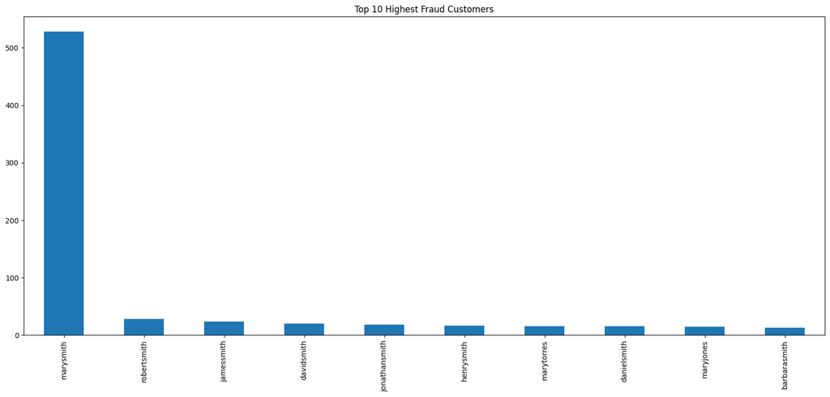

```python
#Filtering out suspected fraud orders
cus = df[(df['Order Status'] == 'SUSPECTED_FRAUD')]
#Top 10 customers with most fraud
cus['Customer Full Name'].value_counts().nlargest(10).plot.bar(figsize=(20,8), title="Top 10 Highest Fraud Customers")
```

```python
df['Order Status'].value_counts()
```

```
COMPLETE           59491
PENDING_PAYMENT    39832
PROCESSING         21902
PENDING            20227
CLOSED             19616
ON_HOLD             9804
SUSPECTED_FRAUD     4062
CANCELED            3692
PAYMENT_REVIEW      1893
Name: Order Status, dtype: int64
```

## **Model Training & Testing**

```python
train_data=df.copy()
```

#### Now adding New columns named Fraud and late delivery which includes the binary values 0 and 1 for the values SUSPECTED FRAUD and Late Delivery in Order status column

```python
train_data['fraud'] = np.where(train_data['Order Status'] == 'SUSPECTED_FRAUD', 1, 0)
train_data['late_delivery']=np.where(train_data['Delivery Status'] == 'Late delivery', 1, 0)
```

**Dropping the values Order Status, Delivery Status, Late Delivery Risk, order month year, order date**

```python
train_data.drop(['Delivery Status','Late_delivery_risk','Order Status','order_month_year','shipping date (DateOrders)'], axis=1, inplace=True)
```

```python
train_data.drop(['_id'],axis=1,inplace=True)
```

```python
train_data.dtypes
```

```
Type                              object
Days for shipping (real)           int64
Days for shipment (scheduled)      int64
Benefit per order                float64
Sales per customer               float64
Category Name                     object
Customer City                     object
Customer Country                  object
Customer Segment                  object
Customer State                    object
Customer Street                   object
Customer Zipcode                 float64
Department Name                   object
Market                            object
Order City                        object
Order Country                     object
Order Item Discount              float64
Order Item Discount Rate         float64
Order Item Quantity                int64
Order Region                      object
Order State                       object
Product Name                      object
Product Price                    float64
Shipping Mode                     object
Order Zipcode                    float64
Customer Full Name                object
order_year                         int64
order_month                        int64
order_week_day                    object
order_hour                         int64
fraud                              int32
late_delivery                      int32
dtype: object
```

```python
train_data['Customer State']=train_data['Customer State'].astype(str)
```

```python
train_data['Customer State'].unique()
```

```
array(['PR', 'CA', 'NY', 'FL', 'MA', 'IL', 'MT', 'PA', 'MI', 'TX', 'DE',
       'GA', 'MD', 'OH', 'HI', 'NJ', 'WI', 'AZ', 'CO', 'MN', 'NC', 'NM',
       'OR', 'SC', 'VA', 'UT', 'WA', 'KY', 'WV', 'RI', 'CT', 'LA', 'TN',
       'DC', 'ND', 'MO', 'IN', 'ID', 'NV', 'KS', 'AR', 'OK', 'AL', 'IA',
       '95758', '91732'], dtype=object)
```

**Here we can see that we have many columns which have the values Object type which can not be trained in Machine learning model so we have to encode them using label encoder for model training**

```python
le = preprocessing.LabelEncoder()
#converting the categorical columns into numeric values by encoding them using label encoder
train_data['Customer Country']  = le.fit_transform(train_data['Customer Country'])
train_data['Market']            = le.fit_transform(train_data['Market'])
train_data['Type']              = le.fit_transform(train_data['Type'])
train_data['Product Name']      = le.fit_transform(train_data['Product Name'])
train_data['Customer Segment']  = le.fit_transform(train_data['Customer Segment'])
train_data['Customer State']    = le.fit_transform(train_data['Customer State'])
train_data['Order Region']      = le.fit_transform(train_data['Order Region'])
train_data['Order City']        = le.fit_transform(train_data['Order City'])
train_data['Category Name']     = le.fit_transform(train_data['Category Name'])
train_data['Customer City']     = le.fit_transform(train_data['Customer City'])
train_data['Department Name']   = le.fit_transform(train_data['Department Name'])
train_data['Order State']       = le.fit_transform(train_data['Order State'])
train_data['Shipping Mode']     = le.fit_transform(train_data['Shipping Mode'])
train_data['order_week_day']    = le.fit_transform(train_data['order_week_day'])
train_data['Order Country']     = le.fit_transform(train_data['Order Country'])
train_data['Customer Full Name']= le.fit_transform(train_data['Customer Full Name'])
train_data['Customer Street']   = le.fit_transform(train_data['Customer Street'])
```

```python
train_data.head()
```

|  | Type | Days for shipping (real) | Days for shipment (scheduled) | Benefit per order | Sales per customer | Category Name | Customer City | Customer Country | Customer Segment | Customer State | ... | Product Price | Shipping Mode | Order Zipcode | Customer Full Name | order_year | order_month | order_week_day | order_hour | fraud | late_delivery |
| --- | --- | --- | --- | --- | --- | --- | --- | --- | --- | --- | --- | --- | --- | --- | --- | --- | --- | --- | --- | --- | --- |
| 0 | 1 | 3 | 4 | 91.250000 | 314.640015 | 40 | 66 | 1 | 0 | 36 | ... | 327.75 | 3 | 0.0 | 1876 | 2018 | 1 | 6 | 22 | 0 | 0 |
| 1 | 3 | 5 | 4 | -21.000000 | 311.359985 | 40 | 66 | 1 | 0 | 36 | ... | 327.75 | 3 | 0.0 | 5378 | 2018 | 1 | 2 | 12 | 0 | 1 |
| 2 | 0 | 4 | 4 | -21.000000 | 309.720001 | 40 | 452 | 0 | 0 | 5 | ... | 327.75 | 3 | 0.0 | 4429 | 2018 | 1 | 2 | 12 | 0 | 0 |
| 3 | 1 | 3 | 4 | 22.860001 | 304.809998 | 40 | 285 | 0 | 2 | 5 | ... | 327.75 | 3 | 0.0 | 12923 | 2018 | 1 | 2 | 11 | 0 | 0 |
| 4 | 2 | 2 | 4 | 134.210007 | 298.250000 | 40 | 66 | 1 | 1 | 36 | ... | 327.75 | 3 | 0.0 | 10638 | 2018 | 1 | 2 | 11 | 0 | 0 |

5 rows × 32 columns

```python
train_data.dtypes
```

```
Type                               int32
Days for shipping (real)           int64
Days for shipment (scheduled)      int64
Benefit per order                float64
Sales per customer               float64
Category Name                      int32
Customer City                      int32
Customer Country                   int32
Customer Segment                   int32
Customer State                     int32
Customer Street                    int32
Customer Zipcode                 float64
Department Name                    int32
Market                             int32
Order City                         int32
Order Country                      int32
Order Item Discount              float64
Order Item Discount Rate         float64
Order Item Quantity                int64
Order Region                       int32
Order State                        int32
Product Name                       int32
Product Price                    float64
Shipping Mode                      int32
Order Zipcode                    float64
Customer Full Name                 int32
order_year                         int64
order_month                        int64
order_week_day                     int32
order_hour                         int64
fraud                              int32
late_delivery                      int32
dtype: object
```

### Data splitting for training and testing at 80:20 ratio

```python
xf=train_data.loc[:, train_data.columns != 'fraud']
yf=train_data['fraud']
xf_train, xf_test,yf_train,yf_test = train_test_split(xf,yf,test_size = 0.2,random_state = 42)
```

```python
xf.shape
```

```
(180519, 31)
```

```python
yf.shape
```

```
(180519,)
```

```python
sc = StandardScaler()
xf_train=sc.fit_transform(xf_train)
xf_test=sc.transform(xf_test)
```

**Now we are using this data for training different models**

```python
def classifiermodel(model_f,xf_train, xf_test,yf_train,yf_test):
    model_f=model_f.fit(xf_train,yf_train) # Fitting train data for fraud detection
    yf_pred=model_f.predict(xf_test)
    accuracy_f=accuracy_score(yf_pred, yf_test) #Accuracy for fraud detection
    recall_f=recall_score(yf_pred, yf_test) #Recall score for  fraud detection
    conf_f=confusion_matrix(yf_test, yf_pred)# fraud detection
    f1_f=f1_score(yf_test, yf_pred)#fraud detection
    print('Model paramters used are :',model_f)
    print('Accuracy of fraud status is        :', (accuracy_f)*100,'%')
    print('Recall score of fraud status is        :', (recall_f)*100,'%')
    print('Conf Matrix of fraud status is        :\n',  (conf_f))
    print('F1 score of fraud status is        :', (f1_f)*100,'%')
```

## Logistic Regression

```python
model_f = LogisticRegression(solver='lbfgs',random_state=0) #the classification model
#Giving inputs to the defined function
classifiermodel(model_f,xf_train, xf_test,yf_train,yf_test)
```

```
Model paramters used are : LogisticRegression(random_state=0)
Accuracy of fraud status is        : 97.76479060491913 %
Recall score of fraud status is        : 56.91318327974276 %
Conf Matrix of fraud status is        :
 [[35120   134]
 [  673   177]]
F1 score of fraud status is        : 30.490956072351423 %
```

### Inferences from logistic regression model:-

Report and Inferences for Logistic Regression Model

Model Parameters: LogisticRegression(random_state=0)

#### Accuracy: 97.76479060491913 %

#### Recall: 56.91318327974276 %

Confusion Matrix:

[[35120 134] [ 673 177]]

#### F1 Score: 30.490956072351423 %

### Inferences:

The Logistic Regression model has a high accuracy of 97.76%, meaning that it correctly predicts the fraud status of most transactions. However, the recall score of 56.91% is relatively low, meaning that the model misses a significant number of fraudulent transactions.

This is likely due to the fact that the model is trained on a dataset of historical transactions, which may not be representative of the current fraud landscape. Fraudsters are constantly developing new techniques, and the model may not be able to detect all of them.

Additionally, the F1 score of 30.49% is also relatively low, indicating that the model does not have a good balance between precision and recall. The model is more precise than it is sensitive, meaning that it is more likely to correctly predict a transaction as non-fraudulent than it is to correctly predict a transaction as fraudulent.

```python
import numpy as np

# List of feature names in the same order as they were used in training
feature_names = ['Type', 'Days for shipping (real)', 'Days for shipment (scheduled)',
       'Benefit per order', 'Sales per customer',
       'Category Name', 'Customer City', 'Customer Country',
       'Customer Segment', 'Customer State', 'Customer Street',
       'Customer Zipcode','Department Name', 'Market',
       'Order City', 'Order Country', 'Order Item Discount',
       'Order Item Discount Rate', 'Order Item Quantity',
       'Order Region', 'Order State', 'Product Name', 'Product Price',
       'Shipping Mode', 'Order Zipcode', 'Customer Full Name', 'order_year',
       'order_month', 'order_week_day', 'order_hour',
       'late_delivery']

coefficients = model_f.coef_[0]
feature_importance = pd.DataFrame({'Feature': feature_names, 'Coefficient': coefficients})
feature_importance = feature_importance.sort_values(by='Coefficient', ascending=False)

print(feature_importance)
```

```
                          Feature  Coefficient
0                            Type     5.647378
1        Days for shipping (real)     1.176294
22                  Product Price     0.096245
19                   Order Region     0.093157
7                Customer Country     0.072129
6                   Customer City     0.071669
18            Order Item Quantity     0.052825
9                  Customer State     0.044356
29                     order_hour     0.032317
17       Order Item Discount Rate     0.029601
24                  Order Zipcode     0.020054
11               Customer Zipcode     0.007569
15                  Order Country     0.003152
28                 order_week_day    -0.003573
```

[output cut: 17 more lines]

### Here are some inferences that can be drawn from the feature coefficients:

- Fraudulent transactions are more likely to be late for delivery. This is likely because fraudsters are often shipping products to addresses that they do not control.
- Fraudulent transactions are more likely to use a specific shipping mode. This may be because fraudsters are using a specific shipping mode to avoid detection.
- Fraudulent transactions are more likely to take a long time to ship. This may be because fraudsters are shipping products from overseas or because they are using stolen credit cards.
- Fraudulent transactions are more likely to have higher product prices. This is likely because fraudsters are targeting high-value items.
- Fraudulent transactions are more likely to occur in certain regions, countries, and cities. This may be due to factors such as the availability of stolen credit cards and the prevalence of fraud in those areas.
- Fraudulent transactions are more likely to involve certain order quantities and item discount rates. This may be because fraudsters are using specific techniques to avoid detection. ####

## **Decision Tree classification**

```python
model_f = tree.DecisionTreeClassifier()
classifiermodel(model_f,xf_train, xf_test,yf_train,yf_test)
```

```
Model paramters used are : DecisionTreeClassifier()
Accuracy of fraud status is        : 99.10536228672723 %
Recall score of fraud status is        : 81.03651354534746 %
Conf Matrix of fraud status is        :
 [[35093   161]
 [  162   688]]
F1 score of fraud status is        : 80.98881695114774 %
```

### Report and Inferences for Decision Tree Classifier Model

Model Parameters: DecisionTreeClassifier

#### Accuracy: 99.10536228672723 %

#### Recall: 81.03651354534746 %

#### Confusion Matrix:

[[35093 161] [ 162 688]]

#### F1 Score: 80.98881695114774 %

### Inferences:

The Decision Tree Classifier model has a very high accuracy of 99.10%, meaning that it correctly predicts the fraud status of most transactions. However, the recall score of 81.04% is slightly lower, meaning that the model misses a small number of fraudulent transactions.

This is likely due to the fact that decision tree models are prone to overfitting. Overfitting occurs when the model learns the training data too well and is unable to generalize to new data. As a result, the model may be able to correctly predict the fraud status of most transactions in the training data, but it may not be able to correctly predict the fraud status of all transactions in the real world.

Despite this, the Decision Tree Classifier model has a high F1 score of 80.99%, indicating that it is a good model for fraud detection. The F1 score is a harmonic mean of the precision and recall scores, and it takes into account both the model's ability to correctly predict fraudulent transactions and its ability to avoid predicting non-fraudulent transactions as fraudulent.

```python
feature_importances = model_f.feature_importances_
feature_names = ['Type', 'Days for shipping (real)', 'Days for shipment (scheduled)',
       'Benefit per order', 'Sales per customer',
       'Category Name', 'Customer City', 'Customer Country',
       'Customer Segment', 'Customer State', 'Customer Street',
       'Customer Zipcode','Department Name', 'Market',
       'Order City', 'Order Country', 'Order Item Discount',
       'Order Item Discount Rate', 'Order Item Quantity',
       'Order Region', 'Order State', 'Product Name', 'Product Price',
       'Shipping Mode', 'Order Zipcode', 'Customer Full Name', 'order_year',
       'order_month', 'order_week_day', 'order_hour',
       'late_delivery']
feature_importance_dict = dict(zip(feature_names, feature_importances))
sorted_feature_importance = sorted(feature_importance_dict.items(), key=lambda x: x[1], reverse=True)
sorted_feature_importance
```

```
[('Days for shipping (real)', 0.12426653000771724),
 ('Customer Street', 0.08685392833299602),
 ('late_delivery', 0.078275883625897),
 ('Customer Full Name', 0.07715830055469211),
 ('Order City', 0.07212824225592375),
 ('Type', 0.05976496881630705),
 ('Shipping Mode', 0.054659680914127186),
 ('Order State', 0.053893306258227344),
 ('Customer Zipcode', 0.04873030418766493),
 ('Order Country', 0.04813965036391099),
 ('order_hour', 0.04008064406002023),
 ('Customer City', 0.03623557693498581),
 ('order_week_day', 0.029180002614291645),
 ('order_month', 0.02802152400814197),
 ('Customer State', 0.027938769963056276),
 ('Order Region', 0.022543058188484205),
 ('Order Zipcode', 0.019396478596912004),
 ('Customer Segment', 0.014603214343607894),
 ('Sales per customer', 0.011107118666610943),
 ('order_year', 0.00976478014140682),
 ('Benefit per order', 0.008016611722707534),
 ('Market', 0.007663525357197507),
 ('Order Item Discount', 0.007642376986483362),
 ('Category Name', 0.00709850856403016),
 ('Product Name', 0.006947506543838994),
 ('Days for shipment (scheduled)', 0.006065897145438492),
 ('Product Price', 0.005034768882438868),
 ('Department Name', 0.0032177869233039),
 ('Order Item Discount Rate', 0.002402372641398342),
 ('Order Item Quantity', 0.0016909125131227385),
 ('Customer Country', 0.0014777698850585667)]
```

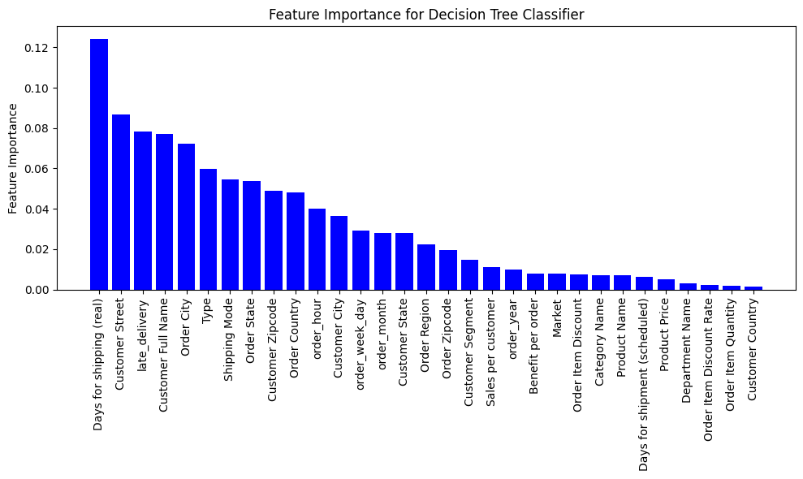

```python
feature_names, feature_importances = zip(*sorted_feature_importance)

# Create a vertical bar plot
plt.figure(figsize=(10, 6))
plt.bar(feature_names, feature_importances, color='blue')
plt.xticks(rotation=90)
plt.ylabel('Feature Importance')
plt.title('Feature Importance for Decision Tree Classifier')
plt.tight_layout()
plt.show()
```

## **K Nearest Neighbour**

```python
model_f = KNeighborsClassifier(n_neighbors=1)
model_l = KNeighborsClassifier(n_neighbors=1)
classifiermodel(model_f,xf_train, xf_test,yf_train,yf_test)
```

```
Model paramters used are : KNeighborsClassifier(n_neighbors=1)
Accuracy of fraud status is        : 98.00576113450033 %
Recall score of fraud status is        : 60.09316770186336 %
Conf Matrix of fraud status is        :
 [[34997   257]
 [  463   387]]
F1 score of fraud status is        : 51.80722891566266 %
```

### Report and Inferences for K-Nearest Neighbors Classifier Model with n_neighbors=1

Model Parameters: KNeighborsClassifier(n_neighbors=1)

#### Accuracy: 98.00576113450033 %

#### Recall: 60.09316770186336 %

#### Confusion Matrix:

[[34997 257] [ 463 387]]

#### F1 Score: 51.80722891566266 %

### Inferences:

The K-Nearest Neighbors Classifier model with n_neighbors=1 has a high accuracy of 98.01%, meaning that it correctly predicts the fraud status of most transactions. However, the recall score of 60.09% is relatively low, meaning that the model misses a significant number of fraudulent transactions.

This is likely due to the fact that the model is using a very small neighborhood size. With a neighborhood size of 1, the model is only considering the most similar transaction to the current transaction when making a prediction. This can lead to the model missing fraudulent transactions that are slightly different from the transactions in the training data.

Additionally, the K-Nearest Neighbors Classifier model is susceptible to noise in the data. If the training data contains a lot of noisy data, the model may not be able to learn the true relationships between the features and the target variable. This can also lead to the model missing fraudulent transactions.

Despite these limitations, the K-Nearest Neighbors Classifier model with n_neighbors=1 is a relatively simple and efficient model to train and predict with. It is also a good model for fraud detection because it can be easily adapted to new data.

## **Random Forest**

```python
model_f = RandomForestClassifier()
model_l = RandomForestClassifier(n_estimators=100, max_depth=10, random_state=0)
classifiermodel(model_f,xf_train, xf_test,yf_train,yf_test)
```

```
Model paramters used are : RandomForestClassifier()
Accuracy of fraud status is        : 98.95856414801683 %
Recall score of fraud status is        : 97.59036144578313 %
Conf Matrix of fraud status is        :
 [[35242    12]
 [  364   486]]
F1 score of fraud status is        : 72.10682492581603 %
```

### Report and Inferences for Random Forest Classifier Model

Model Parameters: RandomForestClassifier()

#### Accuracy: 98.95856414801683 %

#### Recall: 97.59036144578313 %

#### Confusion Matrix:

[[35242 12] [ 364 486]]

#### F1 Score: 72.10682492581603 %

### Inferences:

Random Forest Classifier models are a type of ensemble learning model that combines the predictions of multiple decision trees. This makes them less prone to overfitting than decision trees, and it also allows them to learn complex relationships between the features and the target variable.